# データの可視化（折れ線グラフ）

Sort

2021-01-21

この記事のコードをまとめたものは[Github](https://github.com/FruitGranola?tab=repositories)にあります。

# 使用するパッケージ

```r
library(tidyverse)
library(magrittr)
```

# ggplot2 の theme をあらかじめ設定しておく

```r
theme_set(theme_minimal(base_size = 15))
```

# 使用するデータ

```r
data <- read_csv("Data/House_of_Councilors_1996_2017.csv")
```

# データ内の変数名を確認する

```r
names(data)
```

```
 [1] "year"       "ku"         "kun"        "status"     "name"
 [6] "party"      "party_code" "previous"   "wl"         "voteshare"
[11] "age"        "nocand"     "rank"       "vote"       "eligible"
[16] "turnout"    "exp"        "expm"       "vs"         "exppv"
[21] "smd"        "party_jpn"
```

# 折れ線グラフに使いやすい形にデータを整える

```r
data %<>%
  group_by(year, party_jpn) %>% # 年ごと、各政党ごとに処理を行う
  summarise(smd = sum(smd)) %>%  # 各政党の当選者数を計算
  filter(party_jpn %in% c("自民党", "民主党", "公明党", "共産党")) # 政党を絞る
```

# 折れ線グラフ

## なんの変哲もない折れ線グラフ

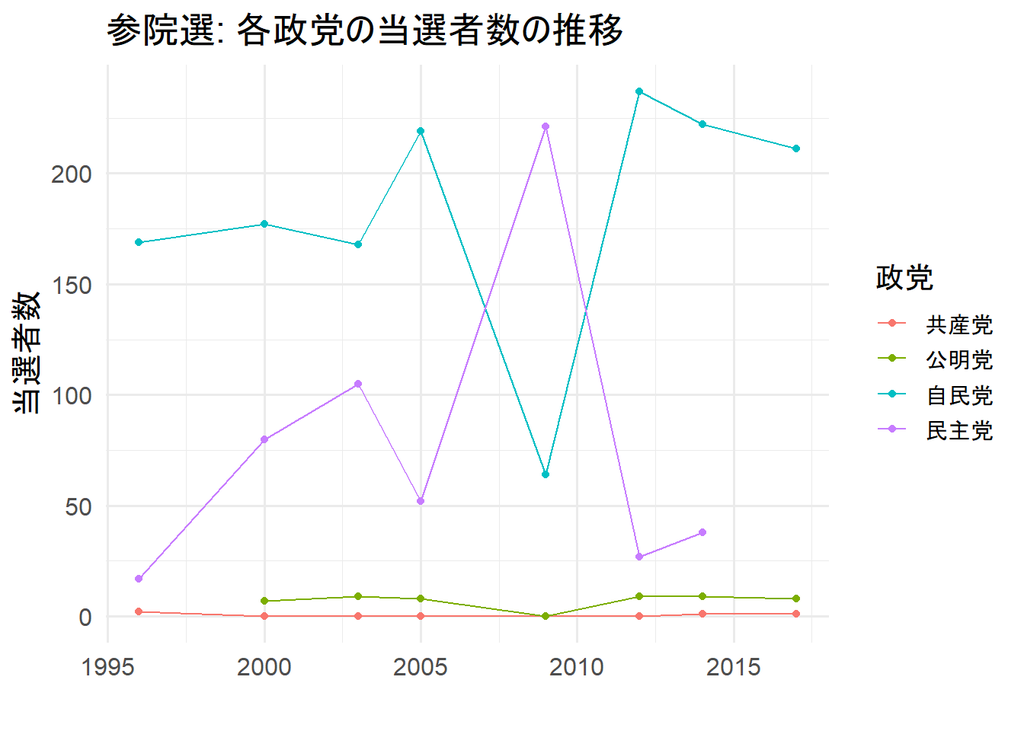

```r
data %>%
  ggplot(aes(x = year, y = smd,
             group = party_jpn,
             color = party_jpn)) +
  geom_point() +
  geom_line() +
  labs(x = "", y = "当選者数",
       title = "参院選: 各政党の当選者数の推移",
       color = "政党")
```

## 政党ごとにpointの形を変える

線を色ごとに変えたほうが視認性が高いが、モノクロで資料を作らなければならない時もある。 その場合は、pointの形を変えると良い。また、線の形を変えても良いだろう。 個人的にはpointの形を変えたほうが視認性が高いと思う。 ちなみに、pointの形を変える場合は`size =`でpointを大きくしたほうが見やすい。

ちなみに、折れ線グラフのlegendはbottomの方が良いという声もある。 legendをbottomにするときは`labs()`で`x = NULL`としたほうが見栄えが良い。

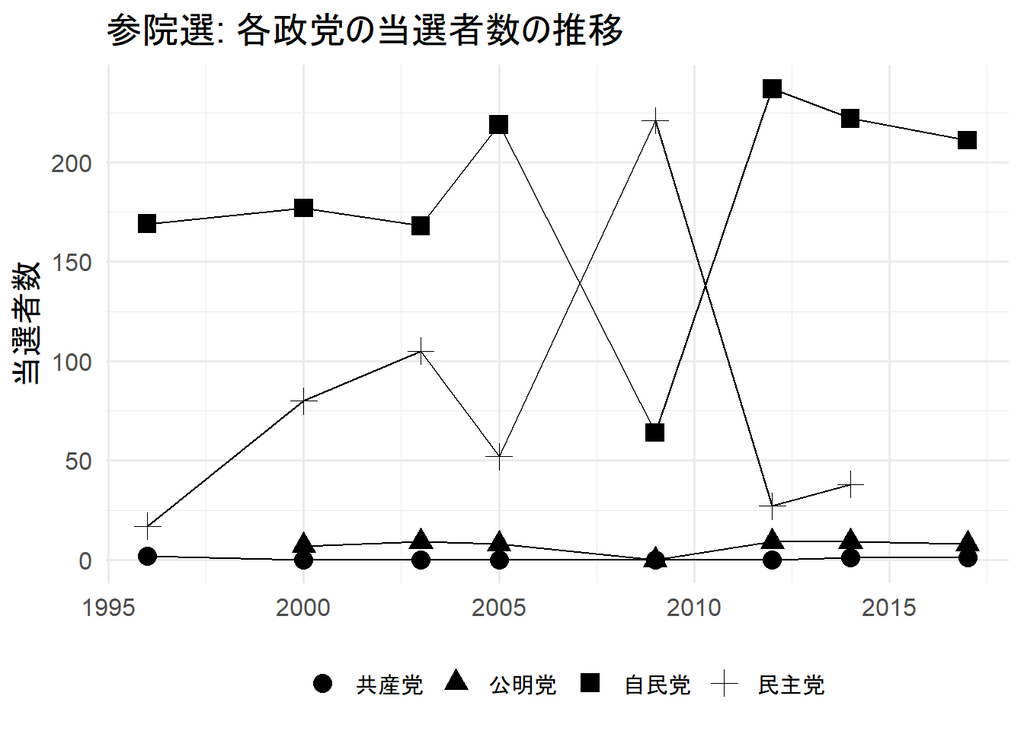

```r
data %>%
  ggplot(aes(x = year, y = smd,
             group = party_jpn)) +
  geom_point(aes(shape = party_jpn),
             size = 4) +
  geom_line() +
  labs(x = NULL, y = "当選者数",
       title = "参院選: 各政党の当選者数の推移",
       shape = NULL) +
  theme(legend.title = element_blank(),
        legend.position = "bottom")
```

## 政党ごとにlineの形を変える

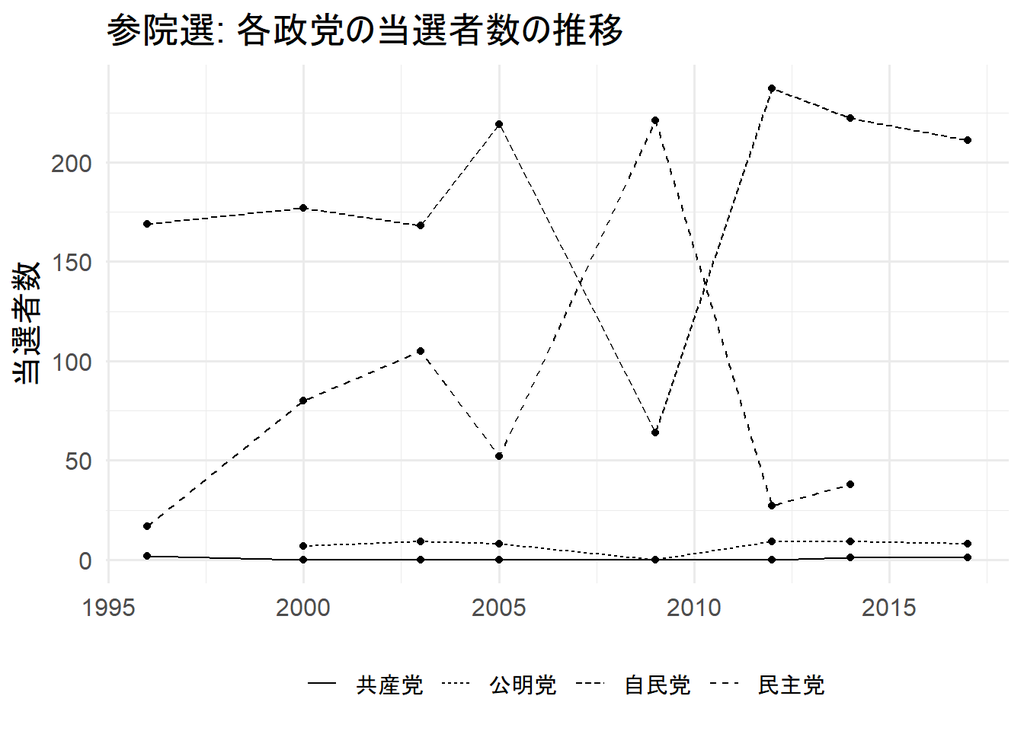

```r
data %>%
  ggplot(aes(x = year, y = smd,
             group = party_jpn)) +
  geom_point() +
  geom_line(aes(linetype = party_jpn)) +
  labs(x = NULL, y = "当選者数",
       title = "参院選: 各政党の当選者数の推移",
       linetype = NULL) +
  theme(legend.position = "bottom")
```

## legendの位置を自由に指定する場合

legendをグラフの中に置いたほうが見やすいという人もいる。 その場合、`legend.position = c(x, y)`でlegendの位置を指定する。

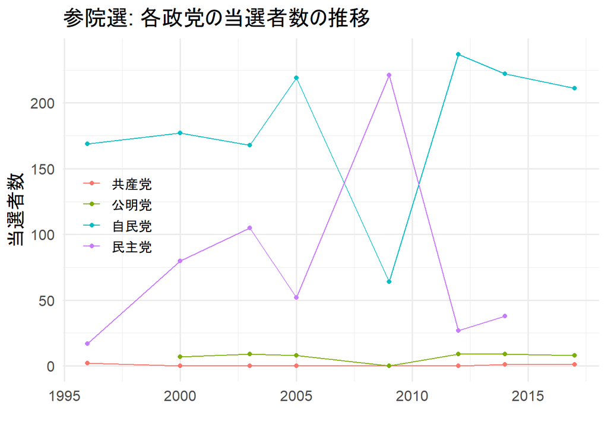

```r
data %>%
  ggplot(aes(x = year, y = smd,
             group = party_jpn,
             color = party_jpn)) +
  geom_point() +
  geom_line() +
  labs(x = "", y = "当選者数",
       title = "参院選: 各政党の当選者数の推移",
       color = "政党") +
  theme(legend.title = element_blank(),
        legend.position = c(0.1, 0.5))
```

## pointの付近に値を載せたい

数値の動きが分かっても、実際の数値が分からない。そんな時は`ggrepel`だ。 `geom_text_repel()`を使えば、適当にいい感じにpointに被らずに数値を載せることができる。 また、数値の載せ方はランダムであるため、`set.seed()`で乱数を固定したほうが良いだろう。

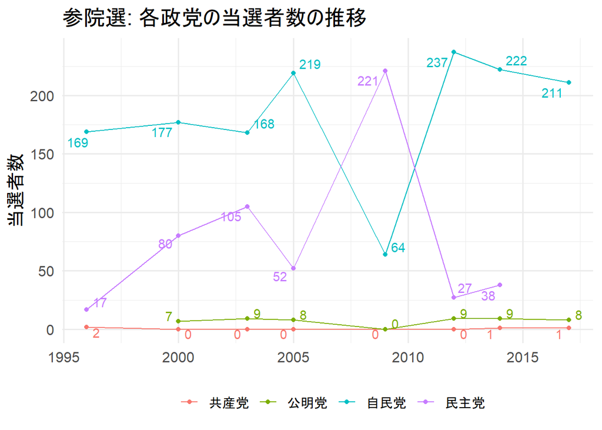

```r
library(ggrepel)

set.seed(1)

data %>%
  ggplot(aes(x = year, y = smd,
             group = party_jpn,
             color = party_jpn)) +
  geom_point() +
  geom_line() +
  labs(x = NULL, y = "当選者数",
       title = "参院選: 各政党の当選者数の推移",
       color = "政党") +
  geom_text_repel(aes(label = smd), show.legend = F) +
  theme(legend.title = element_blank(),
        legend.position = "bottom")
```

## x軸のメモリを調整したい

気にしない人もいるだろうが、pointとメモリの間隔が気に入らない。 このままだとありもしない1995年のデータがあるように見えないだろうか？ それに衆院選は5年刻みではない。 そういうときは`as.factor()`で連続変数ではなく、因子型と指定すれば良いだろう。 また、`paste()`を使えば単位を付けることが可能だ。 もし、それで順番がぐちゃぐちゃになったら、因子型にする前に`arrange()`で順番を変えれば良いはず…(たぶん)

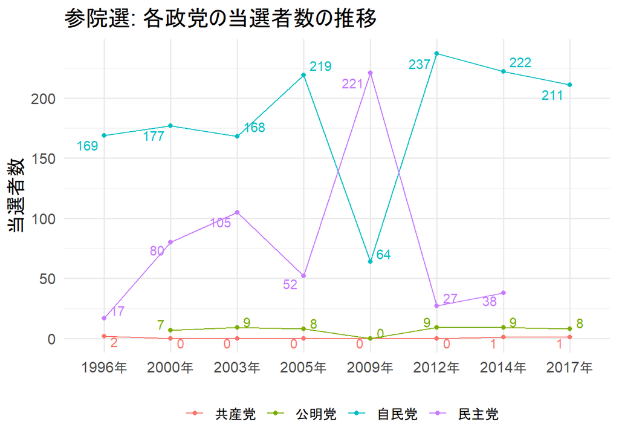

```r
set.seed(1)

data %>%
  mutate(year = paste(as.factor(year), "年", sep = "")) %>%
  ggplot(aes(x = year,
             y = smd,
             group = party_jpn,
             color = party_jpn)) +
  geom_point() +
  geom_line() +
  labs(x = NULL, y = "当選者数",
       title = "参院選: 各政党の当選者数の推移",
       color = "政党") +
  geom_text_repel(aes(label = smd), show.legend = F) +
  theme(legend.title = element_blank(),
        legend.position = "bottom")
```

## 線のハイライト

今回は4つの政党だけを抽出し、可視化しているため見やすい。 しかし、より多くの折れ線を可視化する際には視認性が失われる。 そんな時は、より重要なものにのみ色を付けることで、視認性の高い折れ線グラフを作成できる。 `gghighlight`は`gghighlight(x %in% c("hoge", "hoge"))`で重要な個体を強調できる。

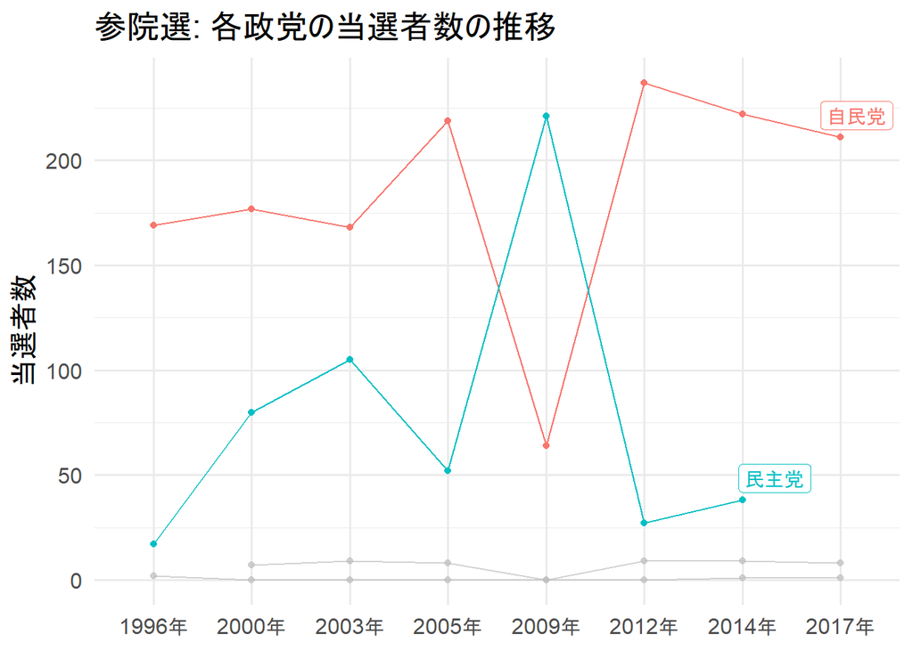

```r
library(gghighlight)

data %>%
  mutate(year = paste(as.factor(year), "年", sep = "")) %>%
  ggplot(aes(x = year,
             y = smd,
             group = party_jpn,
             color = party_jpn)) +
  geom_point() +
  geom_line() +
  gghighlight(party_jpn %in% c("自民党", "民主党")) +
  labs(x = NULL, y = "当選者数",
       title = "参院選: 各政党の当選者数の推移",
       color = "政党") +
  theme(legend.title = element_blank(),
        legend.position = "bottom")
```